# Project 2

Ritesh Penumatsa

2023-11-04

## Introduction

The data comes from Basketball Reference where they keep track of player’s stats such as points per game, field goal percentage, three-pointers made per game, rebounds, assists, etc. These numbers were gathered based on NBA analysts who keep track of these numbers to see how a player is performing. I chose it because it is interesting to see how certain statistics can influence how a player performs and it will be engaging to me since I like to watch basketball. The variables I will be investigating are Player Name, Minutes Played, Points Per Game, Field Goals Made, Turnovers, and Free Throws Made.

[Basketball Reference](https://www.basketball-reference.com/leagues/NBA_2023_per_game.html)

[figure not shown]

## Data Preparation

I used web scraping to import the data into R and I reshaped the data by selecting the columns which consists of the variables being tested and I deselected the rest. In order to process my data, I combined all the variables into a data frame where I can omit any NA’s as well as making sure all the numeric type variables consists of numeric values. One challenge I faced when scraping is I had trouble getting the CSS or X Path of certain columns. Another challenge I had was generating a table to display variable, type, and description.

## Variable Descriptions

```
##                Variable      Type        Description
## Name               Name character      Player's Name
## Minutes         Minutes   numeric     Minutes Played
## Points           Points   numeric    Points Per Game
## Field_Goals Field_Goals   numeric   Field Goals Made
## TurnOvers     TurnOvers   numeric Turnovers Per Game
## FreeThrow     FreeThrow   numeric   Free Throws Made
```

## Univariate Analysis

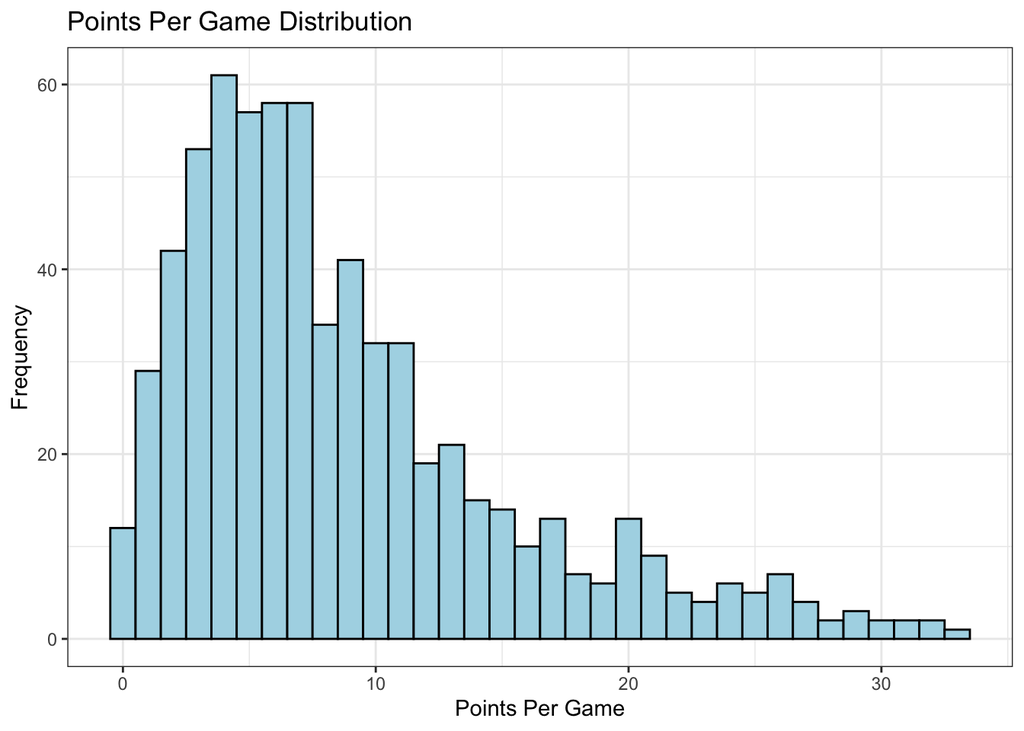

```
##    Min. 1st Qu.  Median    Mean 3rd Qu.    Max.
##   0.000   4.100   6.900   8.859  11.550  33.100
```

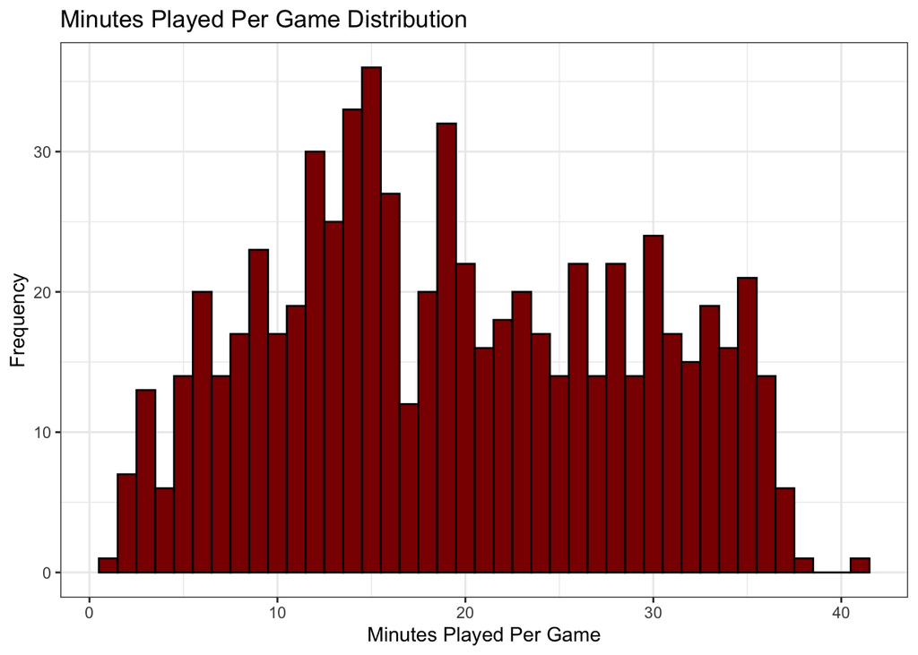

```
##    Min. 1st Qu.  Median    Mean 3rd Qu.    Max.
##    1.00   12.15   18.80   19.46   27.55   41.00
```

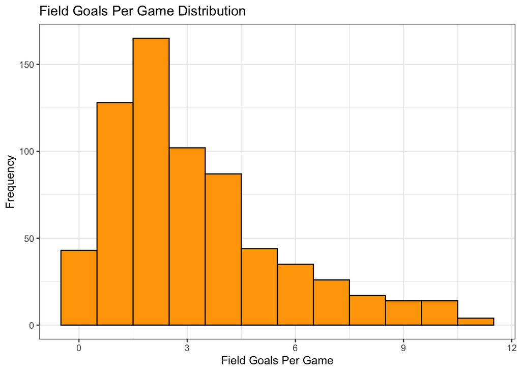

```
##    Min. 1st Qu.  Median    Mean 3rd Qu.    Max.
##   0.000   1.500   2.600   3.249   4.200  11.200
```

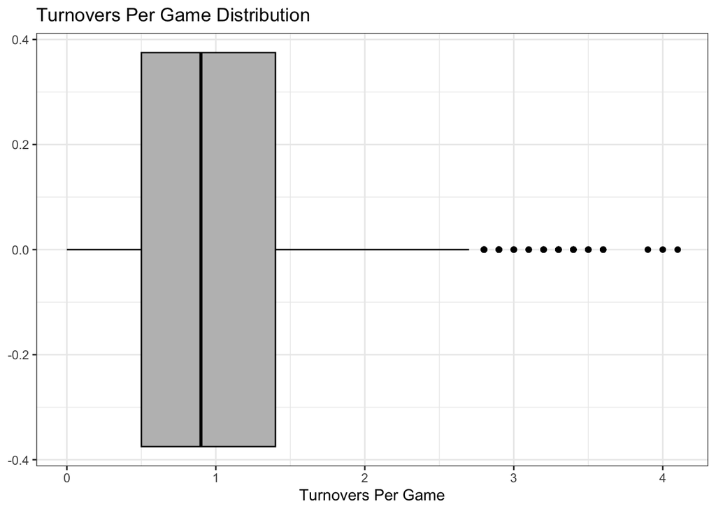

```
##    Min. 1st Qu.  Median    Mean 3rd Qu.    Max.
##   0.000   0.500   0.900   1.067   1.400   4.100
```

For the Field Goals Per Game Distribution, we see the graph is right-skewed. The median field goals per game falls 2-3 per game. But there are a lot of high outliers.

## Multivariate Analysis

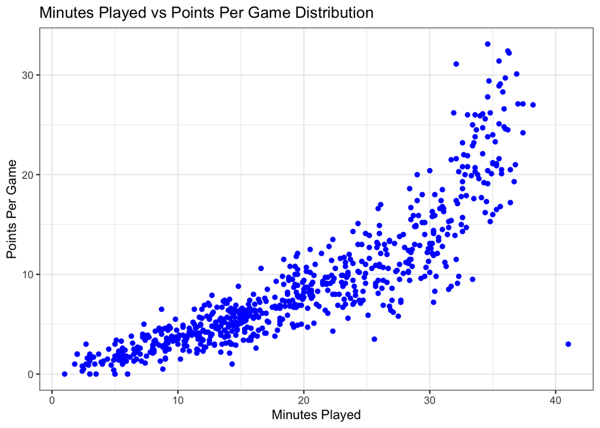

```
##
## Call:
## lm(formula = Points ~ Minutes, data = selected_data)
##
## Residuals:
##     Min      1Q  Median      3Q     Max
## -19.105  -1.740  -0.023   1.424  14.932
##
## Coefficients:
##             Estimate Std. Error t value Pr(>|t|)
## (Intercept) -3.11240    0.28507  -10.92   <2e-16 ***
## Minutes      0.61505    0.01319   46.64   <2e-16 ***
## ---
## Signif. codes:  0 '***' 0.001 '**' 0.01 '*' 0.05 '.' 0.1 ' ' 1
##
## Residual standard error: 3.233 on 677 degrees of freedom
## Multiple R-squared:  0.7627, Adjusted R-squared:  0.7623
## F-statistic:  2176 on 1 and 677 DF,  p-value: < 2.2e-16
```

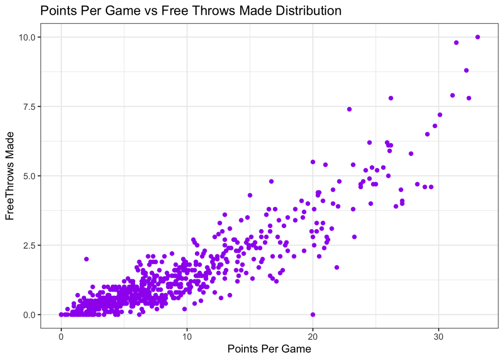

```
##
## Call:
## lm(formula = Points ~ FreeThrow, data = selected_data)
##
## Residuals:
##      Min       1Q   Median       3Q      Max
## -11.5772  -1.8195  -0.3624   1.4554  16.6695
##
## Coefficients:
##             Estimate Std. Error t value Pr(>|t|)
## (Intercept)  3.33049    0.14983   22.23   <2e-16 ***
## FreeThrow    4.04559    0.07445   54.34   <2e-16 ***
## ---
## Signif. codes:  0 '***' 0.001 '**' 0.01 '*' 0.05 '.' 0.1 ' ' 1
##
## Residual standard error: 2.866 on 677 degrees of freedom
## Multiple R-squared:  0.8135, Adjusted R-squared:  0.8132
## F-statistic:  2953 on 1 and 677 DF,  p-value: < 2.2e-16
```

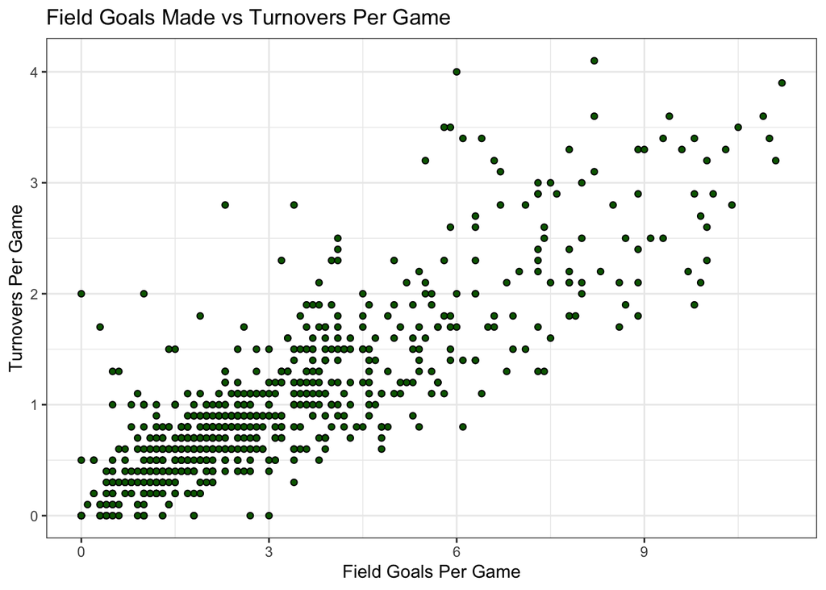

```
##
## Call:
## lm(formula = Field_Goals ~ TurnOvers, data = selected_data)
##
## Residuals:
##     Min      1Q  Median      3Q     Max
## -5.5675 -0.6364 -0.1422  0.6150  4.4810
##
## Coefficients:
##             Estimate Std. Error t value Pr(>|t|)
## (Intercept)  0.59662    0.08190   7.285 8.99e-13 ***
## TurnOvers    2.48544    0.06143  40.458  < 2e-16 ***
## ---
## Signif. codes:  0 '***' 0.001 '**' 0.01 '*' 0.05 '.' 0.1 ' ' 1
##
## Residual standard error: 1.279 on 677 degrees of freedom
## Multiple R-squared:  0.7074, Adjusted R-squared:  0.707
## F-statistic:  1637 on 1 and 677 DF,  p-value: < 2.2e-16
```

[figure not shown]

```
##
## Call:
## lm(formula = Minutes ~ TurnOvers, data = selected_data)
##
## Residuals:
##      Min       1Q   Median       3Q      Max
## -23.0429  -4.2940  -0.2254   4.0438  16.0537
##
## Coefficients:
##             Estimate Std. Error t value Pr(>|t|)
## (Intercept)   9.6475     0.3769   25.60   <2e-16 ***
## TurnOvers     9.1977     0.2827   32.54   <2e-16 ***
## ---
## Signif. codes:  0 '***' 0.001 '**' 0.01 '*' 0.05 '.' 0.1 ' ' 1
##
## Residual standard error: 5.884 on 677 degrees of freedom
## Multiple R-squared:   0.61,  Adjusted R-squared:  0.6094
## F-statistic:  1059 on 1 and 677 DF,  p-value: < 2.2e-16
```

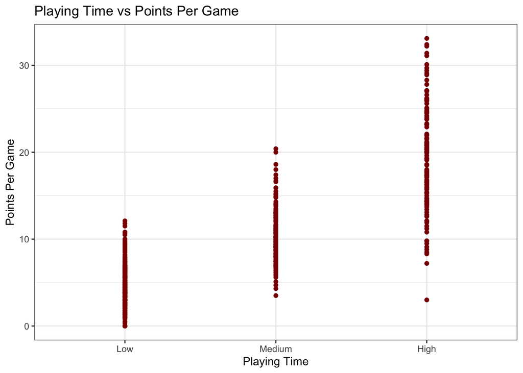

```
##
## Call:
## lm(formula = Points ~ Playing_Time_Category, data = selected_data)
##
## Residuals:
##     Min      1Q  Median      3Q     Max
## -16.507  -2.125  -0.170   1.930  13.593
##
## Coefficients:
##                             Estimate Std. Error t value Pr(>|t|)
## (Intercept)                   4.5700     0.1807   25.29   <2e-16 ***
## Playing_Time_CategoryMedium   5.9553     0.3191   18.66   <2e-16 ***
## Playing_Time_CategoryHigh    14.9372     0.3632   41.12   <2e-16 ***
## ---
## Signif. codes:  0 '***' 0.001 '**' 0.01 '*' 0.05 '.' 0.1 ' ' 1
##
## Residual standard error: 3.509 on 676 degrees of freedom
## Multiple R-squared:  0.7208, Adjusted R-squared:   0.72
## F-statistic: 872.8 on 2 and 676 DF,  p-value: < 2.2e-16
```

The Playing Time Per Game vs Points Per Game displays a scatter plot where the Playing Time is separating into three different categories: low, medium, high. It displays the points per game for each of the three categories. The points per game is greatest in high playing time and lowest in low playing time.

The Minutes Per Game vs Turnovers Per Game displays a scatter plot comparing the relationship between Minutes Per Game and Turnovers per Game. We can conclude as a player plays more minutes they have a higher probability of committing more turnovers.

The Field Goal vs Turnovers per game displays a scatter plot comparing these two statistics. Since there is a positive strong linear correlation between them, we can be safe to conclude as a player shoots the ball more they are likely to commit more turnovers.

The Points Per Game vs Free Throws per game displays a scatter plot comparing these two statistics. Since there is a positive strong correlation between them, we can be safe to conclude as a player score more points they are likely to to have more made free throws.

The Minutes vs Points Per Game distribution displays a scatter plot comparing these two statistics. Since there is a positive strong correlation between them, we can be safe to conclude as a player plays more minutes they are likely to score more points.

## Reproducibility

[Private GitHub](https://github.com/rp37458/Project_2/tree/main)

The GitHub Repository consists of rmd file, html file resulted from knitting, image, and readMe file.

## Conclusion

From the analysis tested, there was a positive strong correlation between Minutes vs Points Per Game, Points Per Game vs Free Throws per game, Field Goal vs Turnovers, Minutes Per Game vs Turnovers Per Game, and Playing Time Per Game vs Points Per Game. It means as one of these variables were directly proportions the another as when one increases the other increases and vise versa. For points per game distribution, we can see 50% of the NBA players falls between 4.1 to 11.5 as the league average is about 8 ppg. For minutes per game, 50% of NBA players play on average between 12 to 28 minutes, 50% of NBA players make between 1 to 4 shots per game, and 50% of NBA players have an average of 0.5 to 1.4 turnovers per game. They were what I expected.

## References

[Basketball](https://www.basketball-reference.com/leagues/NBA_2023_per_game.html)

[Basketball Logo](https://twitter.com/NBAPR/photo)